# Lab 4 - Linear Regression

## Exercise 4.3 (Optional)

In this exercise you will create some simulated data and will fit simple linear regression models to it. Make sure to use `set.seed(1)` prior to starting part (a) to ensure consistent results.

1. Using the `rnorm()` function, create a vector, `x`, containing 100 observations drawn from a $N(0,1)$ distribution. This represents a feature, `X`.

```r
#set.seed() create simulated values that are reproducible. set.seed(5) means that everytime simulation is done, the first 5 will be the same.
set.seed(1)
x <- rnorm(100, mean = 0, sd = 1)
```

2. Using the `rnorm()` function, create a vector, `eps`, containing 100 observations drawn from a $N(0,0.25)$ distribution i.e. a normal distribution with mean zero and variance 0.25.

```r
set.seed(1)
eps <- rnorm(100, mean = 0, sd = 0.5)
```

3. Using `x` and `eps`, generate a vector `y` according to the model
   $$Y =
   -1 + 0.5X + \epsilon$$

```r
y = -1 + 0.5 * x + eps
```

What is the length of the vector `y`? What are the values of $\beta_0$ and $\beta_1$ in this linear model?

```r
length(y)
```

```
## [1] 100
```

**length of vector y = 100; $\beta_0$ = -1 and $\beta_1$ = 0.5.**

4. Create a scatterplot displaying the relationship between `x` and `y`. Comment on what you observe.

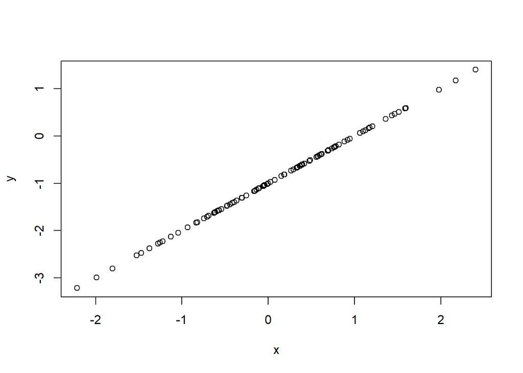

```r
plot(y ~ x)
```

5. Fit a least squares linear model to predict `y` using `x`. Comment on the model obtained. How do $\hat{\beta}_0$ and $\hat{\beta}_1$ compare to $\beta_0$ and $\beta_1$?

```r
fit3 <- lm(y ~ x)
summary(fit3)
```

```
##
## Call:
## lm(formula = y ~ x)
##
## Residuals:
##        Min         1Q     Median         3Q        Max
## -6.267e-16 -1.255e-16 -3.203e-17  3.420e-17  2.266e-15
##
## Coefficients:
##               Estimate Std. Error    t value Pr(>|t|)
## (Intercept) -1.000e+00  3.237e-17 -3.089e+16   <2e-16 ***
## x            1.000e+00  3.596e-17  2.781e+16   <2e-16 ***
## ---
## Signif. codes:  0 '***' 0.001 '**' 0.01 '*' 0.05 '.' 0.1 ' ' 1
##
## Residual standard error: 3.214e-16 on 98 degrees of freedom
## Multiple R-squared:      1,  Adjusted R-squared:      1
## F-statistic: 7.734e+32 on 1 and 98 DF,  p-value: < 2.2e-16
```

6. Display the least squares line on the scatterplot obtained in (d). Draw the population regression line on the plot, in a different color. Use the `legend()` command to create an appropriate legend.

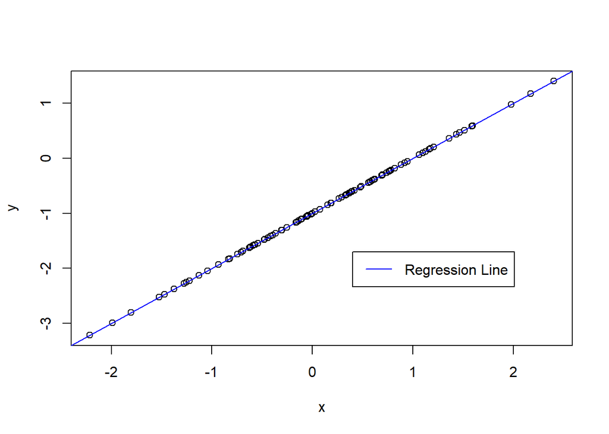

```r
{
plot(y ~ x)
abline(fit3, col = "blue")
legend(x=0.4, y=-1.7, c("Regression Line"), col = "blue", lwd = 1, bty = 1)
}
```

7. Now fit a polynomial regression model that predicts $y$ using $x$ and $x^2$. Is there evidence that the quadratic term improves the model fit? Explain your answer.

```r
fit4 <- lm(y ~ poly(x,2))
summary(fit4)
```

```
##
## Call:
## lm(formula = y ~ poly(x, 2))
##
## Residuals:
##        Min         1Q     Median         3Q        Max
## -1.398e-15 -1.277e-16 -2.763e-17  7.712e-17  2.361e-15
##
## Coefficients:
##               Estimate Std. Error    t value Pr(>|t|)
## (Intercept) -8.911e-01  3.404e-17 -2.618e+16   <2e-16 ***
## poly(x, 2)1  8.937e+00  3.404e-16  2.625e+16   <2e-16 ***
## poly(x, 2)2 -5.457e-16  3.404e-16 -1.603e+00    0.112
## ---
## Signif. codes:  0 '***' 0.001 '**' 0.01 '*' 0.05 '.' 0.1 ' ' 1
##
## Residual standard error: 3.404e-16 on 97 degrees of freedom
## Multiple R-squared:      1,  Adjusted R-squared:      1
## F-statistic: 3.446e+32 on 2 and 97 DF,  p-value: < 2.2e-16
```

8. Repeat (a)-(f) after modifying the data generation process in such a way that there is less noise in the data. The model should remain the same. You can do this by decreasing the variance of the normal distribution used to generate the error term $\epsilon$ in (b). Describe your results.

```r
set.seed(1)
x1 = rnorm(100, mean = 0, sd = 1)
eps1 = rnorm(100, mean = 0, sd = 0.1)
y1 = -1 + 0.5 * x1 + eps1
fit5 <- lm(y1 ~ x1)
summary(fit5)
```

```
##
## Call:
## lm(formula = y1 ~ x1)
##
## Residuals:
##      Min       1Q   Median       3Q      Max
## -0.18768 -0.06138 -0.01395  0.05394  0.23462
##
## Coefficients:
##              Estimate Std. Error t value Pr(>|t|)
## (Intercept) -1.003769   0.009699  -103.5   <2e-16 ***
## x1           0.499894   0.010773    46.4   <2e-16 ***
## ---
## Signif. codes:  0 '***' 0.001 '**' 0.01 '*' 0.05 '.' 0.1 ' ' 1
##
## Residual standard error: 0.09628 on 98 degrees of freedom
## Multiple R-squared:  0.9565, Adjusted R-squared:  0.956
## F-statistic:  2153 on 1 and 98 DF,  p-value: < 2.2e-16
```

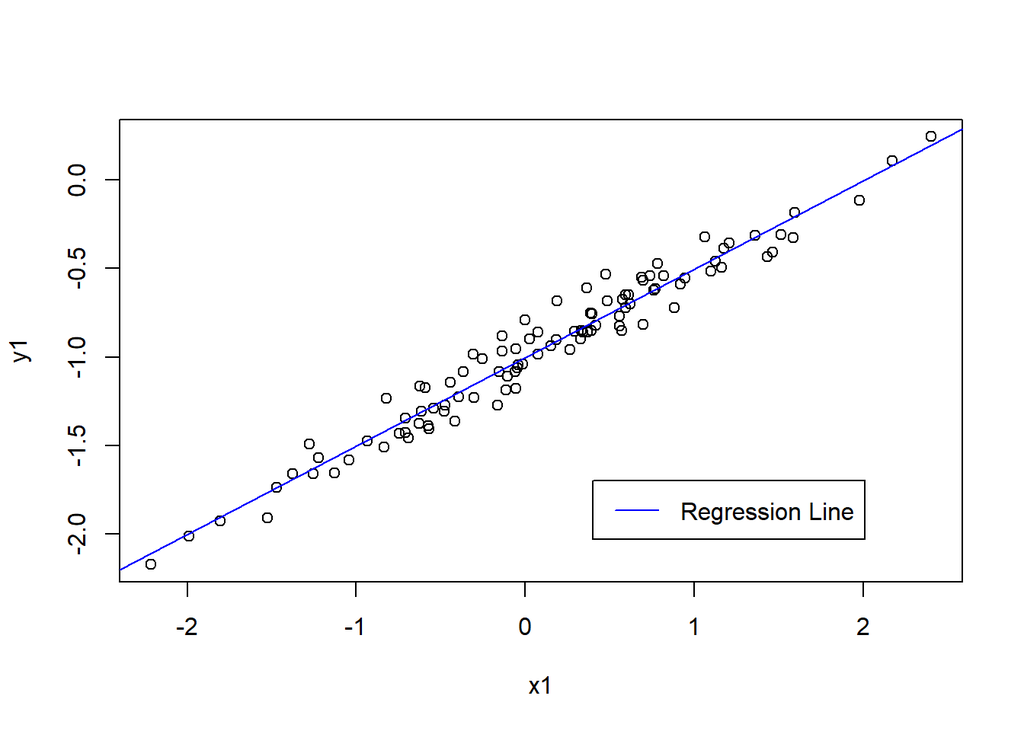

```r
{
plot(y1 ~ x1)
  abline(fit5, col = "blue")
legend(x=0.4, y=-1.7, c("Regression Line"), col = "blue", lwd = 1, bty = 1)
}
```

1. Repeat (a)-(f) after modifying the data generation process in such a way that there is more noise in the data. The model should remain the same. You can do this by increasing the variance of the normal distribution used to generate the error term $\epsilon$ in (b). Describe your results.

```r
set.seed(1)
x2 = rnorm(100, mean = 0, sd = 1)
eps2 = rnorm(100, mean = 0, sd = 1)
y2 = -1 + 0.5 * x2 + eps2
fit7 <- lm(y2 ~ x2)
summary(fit7)
```

```
##
## Call:
## lm(formula = y2 ~ x2)
##
## Residuals:
##     Min      1Q  Median      3Q     Max
## -1.8768 -0.6138 -0.1395  0.5394  2.3462
##
## Coefficients:
##             Estimate Std. Error t value Pr(>|t|)
## (Intercept) -1.03769    0.09699 -10.699  < 2e-16 ***
## x2           0.49894    0.10773   4.632 1.12e-05 ***
## ---
## Signif. codes:  0 '***' 0.001 '**' 0.01 '*' 0.05 '.' 0.1 ' ' 1
##
## Residual standard error: 0.9628 on 98 degrees of freedom
## Multiple R-squared:  0.1796, Adjusted R-squared:  0.1712
## F-statistic: 21.45 on 1 and 98 DF,  p-value: 1.117e-05
```

**The new model has all regressors statistically significant to the model. However, the new adjusted R-squared value is 0.1712 indicating that lesser variability is explained by the model, thus proving that this model doesn’t fit the data well.**

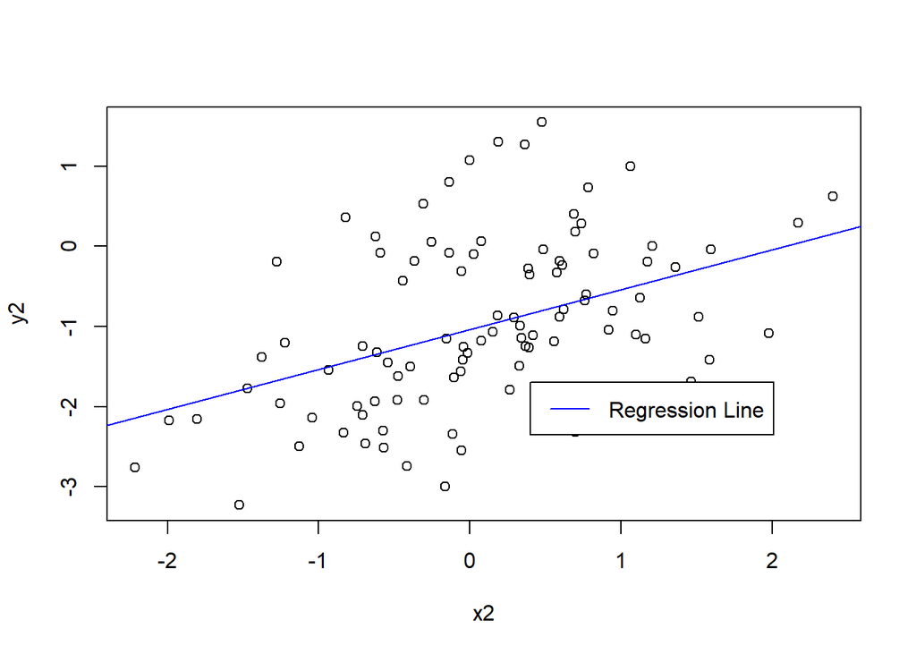

```r
{
plot(y2 ~ x2)
  abline(fit7, col = "blue")
legend(x=0.4, y=-1.7, c("Regression Line"), col = "blue", lwd = 1, bty = 1)
}
```

10. What are the confidence intervals for $\beta_0$ and $\beta_1$ based on the original data set, the noisier data set, and the less noisy data set? Comment on your results.

```r
#Original Dataset
confint(fit3)
```

```
##             2.5 % 97.5 %
## (Intercept)    -1     -1
## x               1      1
```

```r
#Less Noisy Dataset
confint(fit5)
```

```
##                  2.5 %     97.5 %
## (Intercept) -1.0230161 -0.9845224
## x1           0.4785159  0.5212720
```

```r
#Noisier Dataset
confint(fit7)
```

```
##                  2.5 %     97.5 %
## (Intercept) -1.2301607 -0.8452245
## x2           0.2851588  0.7127204
```

**The noisier the dataset, the wider the confidence interval.**